# Structural Bayesian Techniques for Experimental and Behavioral Economics

May 2024

## Structural Bayesian Techniques for Experimental and Behavioral Economics

## Introduction

## Answering research questions with structural econometrics

I have a model and data, and I want to …

- **Estimate the parameters** in the model
- Compute **economically meaningfully quantities** from the parameters in my model
- **Quantify how much heterogeneity** is present between participants in my model’s parameters
- Use my model to make a **prediction** about behavior in another setting

But you should also **quantify the uncertainty** you have in all of these

## Estimating parameters in a model

My model says that parameter(s) are important, so I want to know what they are.

For example, some preference models

\[ \begin{aligned} \text{Risk: }& U(L) = E\left(\frac{X^{1-r}}{1-r}\mid L\right) \\ \text{Time: }& U(x) = \sum_{t=0}^{\infty} \delta^t x_t\\ \text{Other-regarding: }& U_i(x)=x_i-\frac{\alpha}{n-1}\sum_{j\neq i}\max\left\{x_j-x_i,0\right\}\\ &\quad\quad \quad\quad-\frac{\beta}{n-1}\sum_{j\neq i}\max\left\{x_i-x_j,0\right\} \end{aligned} \]

## Computing economically meaningful quantities

What I really want to do is interpret a **transformation** of the parameters.

E.g. a certainty equivalent:

\[ \begin{aligned} U(L)&= E\left(\frac{X^{1-r}}{1-r}\mid L\right)\\ \\ & C(L)\sim L\\ C(L)&= \left[E\left(X^{1-r}\mid L\right)\right]^\frac{1}{1-r} \end{aligned} \]

\(C(L)\) converts expected utility units (hard to interpret and compare) into dollars

## Quantifying heterogeneity

Parameter \(\theta\) is likely *not* the same for every participant

Assume (for example):

\[ \theta_i\sim iid N(\mu,\sigma^2) \]

Estimate and interpret \(\mu\) and \(\sigma\)

## Making predictions

Parameters \(\theta\) imply something about choices \(y\) in scenario \(S\):

\[ p(y\mid\theta,S) \]

- For the same participant in another scenario
  - Model evaluation
- For different participants in similar scenarios
  - Scaling an experiment up from a pilot
- For different participants in a new scenario
  - Designing a new experiment

## Answering research questions with structural econometrics – more

I have **more than one model**, and I want to …

- **Classify** participants into one model
- Determine **which model best organizes the data**
- Determine **what fraction of participants** behave according to each model
- Use these models to make a **prediction** about behavior in another setting

## Classifying participants and data

Two models \(M_1\) and \(M_2\) imply different things about choices:

- Bracket decisions narrowly or broadly?
- CRRA or CARA utility functions?
- Exponential or hyperbolic discounting?
- Quantal response equilibrium or a learning model?

Which model seems to be the better model for a participant’s data?

Which model seems to be the better model for the data overall?

## But both (all) models could be important

Each participant could use either \(M_1\) **or** \(M_2\)

Participants could sometimes use \(M_1\) **and** sometimes use \(M_2\)

## Making predictions with more than one model

A combination of \(M_1\) and \(M_2\) could do better than any one on its own

## What could these models look like?

A **utility function** our participants could be maximizing

- E.g. risk preferences

An **equilibrium concept** in a game

- E.g. Quantal response equilibrium

A set of economically-relevant **decision rules**

- E.g. Strategy frequency estimation

## Structural estimation

Take an **economic model** of how data are generated, and **estimate the parameters** in this model

Then:

- Interpret the estimated parameters
- Derive implications of the estimated parameter values

## Comparison with traditional reduced-form experimental procedures

Theory says that choices \(y\mid D\) will (or will not) be different depending on treatment conditions \(D\).

Design an experiment to test whether or not \(y\mid D_1\) has the same mean, distribution, etc. as \(y\mid D_2\)

Compare treatment outcomes, e.g. with linear regression:

\[ y_{i,t}=\beta_0+\beta_1 D_{i,t}+\epsilon_{i,t},\quad H_0: \ \beta_1=0 \]

## Here’s the differece

**Reduced-form:**

- Model says something about \(y\mid D\)
- Estimate/test for differences between treatments

**Structural:**

- Model **is** a distribution \(y\mid \theta, D\)
- Estimate \(\theta\)

We will draw a straight line through the data only if this is what the model says the data will look like!

## The structural approach is *very* different to traditional experimental techniques

Not necessarily a need for:

- Randomization into treatments
- Any treatments at all
- Designs that could falsify a theory

But you can still use data from a traditionally-designed experiment.

- Structural estimation is a *complement* to the traditional experimental approach
- But: traditional experiment designs may not be optimized for structural estimation

## Structural models for economic experiments

I have a model that describes how participants will make decisions in my experiment.

I will teach you about **probabilistic** models, which specify a probability distribution over decisions in the experiment.

- **Likelihood** \(p(y\mid\theta)\): If you tell me the model’s parameters, I can simulate data for my experiment.
- **Prior** \(p(\theta)\): I have beliefs about what these parameters will look like before running the experiment

Together, I can simulate data for my experiment that is consistent with my prior beliefs about my model’s parameters

\[ p(y)= \int_{\Theta}p(y\mid\theta)p(\theta)\mathrm d\theta = E_\theta\left[p(y\mid\theta)\right] \]

## Applying Bayes’ theorem to learn from data

Bayes’ theorem in general:

\[ \begin{aligned} p(A,B)&=p(A\mid B) p(B)=p(B\mid A)p(A)\\ \text{therefore: }\quad p(A\mid B)&=\frac{p(B\mid A)p(A)}{p(B)} \end{aligned} \]

Bayesian statistics: \(A=\theta\) (parameters), \(B=y\) (data):

\[ \begin{aligned} p(\theta\mid y)&=\frac{p(y\mid\theta) p(\theta)}{p(y)}\propto p(y\mid\theta)p(\theta)=p(y,\theta) \end{aligned} \]

\(p(y\mid\theta)\) is the **likelihood**: given \(\theta\), what will my data look like?

\(p(\theta)\) is the **prior**: what are my beliefs about \(\theta\) before running my experiment?

## Why Bayes?

This is **the right way** to learn from data, according to math!

## Why Bayes? More practically

The alternative is (usually) maximum likelihood.

- Bayes often turns a difficult maximization problem into a slightly less difficult simulation problem.
- The technology to do this simulation has improved *immensely*

Better handling of un-observable heterogeneity

- Data augmentation vs. integrating the likelihood
- Handled particularly well by Hamiltonian Monte Carlo (This is what *Stan* does)
- Participants are heterogeneous!

## Applying Bayes’ rule to structural models in experiments

\[ \begin{aligned} p(\theta\mid y)&=\frac{p(y\mid\theta) p(\theta)}{p(y)}\propto p(y\mid\theta)p(\theta) \end{aligned} \]

A typical procedure:

\(u(y;\theta,x)\): A (deterministic) **utility function** over choices \(y\) given experimental conditions \(x\) and parameters \(\theta\)

\(p(y\mid u,\theta)\): A **stochastic choice rule**

\(p(\theta)\): a prior for our model’s parameters

## Some components of a structural model: Utility function

If present, this is usually the thing we are most interested in

\(u(y;\theta,x)\): A (deterministic) **utility function** over choices \(y\) given experimental conditions \(x\). For example:

Risk preferences: \[ u(y;\theta,x)=\sum_{k=1}^K p^y_k \frac{x_k^{1-r}}{1-r} \]

Time preferences:

\[ u(y;\theta,x)=\sum_{t=0}^\infty \delta^t y_t \]

## The components of a structural model: A probabilistic choice rule

Converts a **deterministic** prediction into a **probabilistic** one.

- Specifies a probability distribution over actions given utility of taking these actions
- Necessary for constructing a likelihood
- Behaviorally plausible

\[ \begin{aligned} \text{logit choice: } p(a\mid x,\theta)&=\frac{\exp(\lambda u_a(x,\theta))}{\sum_{j\in A}\exp(\lambda u_j(x,\theta))}\\ \text{optimal plus error: } y\mid x,\theta&\sim \arg\max_{y'\in A}u(y',x,\theta)+\epsilon,\quad \epsilon\sim N(0,\sigma^2) \end{aligned} \]

## The components of a structural model: A prior

\[p(\theta)\]

Our belief about \(\theta\) before we observe our data

What are:

- Likely values?
- Unlikely but possible values?
- Stupidly unlikely but still possible values?
- Impossible values?
- Values which pose a problem for estimation?

A **formal mathematical statement** of this

## How can we estimate these models?

The posterior distribution \(p(\theta\mid y)\) is in general not known in closed form.

- Fortunately, we can *sample* from it.
- We then report *summary statistics* of these simulated draws (e.g. means, standard deviations).

The more “traditional” Bayesian approach, Gibbs sampling: needs exact conditional distributions for subsets of the parameters.

- Great if you want to only work with linear models (I don’t)
  - Conjugate priors
- Feasible for (mostly non-linear) structural applications, but very slow (see my job market paper (Bland 2019))
- More **user-intensive**

## A better way for estimating structural models

Most of the computationally difficult stuff is in handling the non-linearities, which do not work well with a Gibbs sampler.

Instead, use a *probabilistic programming language* that takes care of all of this!

I will teach you about *Stan* (Carpenter et al. 2017):

- Free, and callable within *R*, *Python*, *Matlab*, *Stata*, etc
- Allows us to code up models in a similar way to how we might write them down
- Uses Hamiltonian Monte Carlo: Fast!
- Especially well suited to handling hierarchical models
- In-built diagnostics

## Example *Stan* program for estimating a Normal distribution

```c
data {
  int<lower=0> N; // number of observations in data
  vector[N] y; // data
  vector[2] prior_mu; // prior for parameter mu (mean and sd)
  real<lower=0> prior_sigma; // prior for sigma (half-cauchy)
}
parameters {
  real mu; // mean of distribution
  real<lower=0> sigma; // standard deviation of distribution
}
model {
  y ~ normal(mu, sigma); // likelihood contribution
  mu ~ normal(prior_mu[1],prior_mu[2]); // prior for mu
  sigma ~ cauchy(0.0,prior_sigma); // prior for sigma
}
```

## What information does *Stan* need? **Overview**

Instructions on how to compute the log joint density of parameters and data:

\[ \log p(y,\theta)=\underbrace{\log p(y\mid\theta)}_\text{likelihood}+\underbrace{\log p(\theta)}_\text{prior} \]

## What information does *Stan* need? **Data block**

A description of the data (any any other information you want to pass to *Stan*)

- names
- data types, e.g. `int`, `real`, `vector`, etc.
- array sizes
- bounds (optional)

```c
data {
  int<lower=0> N; // number of observations in data
  vector[N] y; // data
  vector[2] prior_mu; // prior for parameter mu (mean and sd)
  real<lower=0> prior_sigma; // prior for sigma (half-cauchy)
}
```

## What information does *Stan* need? **Parameters block**

- names
- bounds
- parameter types
  - Must be continuous variables
  - `real`, `vector`, `matrix`, `simplex`, `corr_matrix` etc. allowed
  - `int` not allowed

```c
parameters {
  real mu; // mean of distribution
  real<lower=0> sigma; // standard deviation of distribution
}
```

## What information does *Stan* need? **Model block**

Instructions on how to compute the `target`:

\[ \log p(y,\theta)=\log p(y\mid\theta)+\log p(\theta) \]

```c
model {
  y ~ normal(mu, sigma); // likelihood contribution
  mu ~ normal(prior_mu[1],prior_mu[2]); // prior for mu
  sigma ~ cauchy(0.0,prior_sigma); // prior for sigma
}
```

Alternatively:

```c
model {
  target += normal_lpdf(y | mu, sigma); // likelihood contribution
  target += normal_lpdf(mu | prior_mu[1],prior_mu[2]); // prior for mu
  target += cauchy_lpdf(sigma | 0.0,prior_sigma); // prior for sigma
}
```

## Optional *Stan* blocks

`functions`: Specify user-defined functions

`transformed data`: Data manipulations

`transformed parameters`: Calculate functions of parameters and data that can be used in the `model` block (slow-ish)

`generated quantities`: Calculate functions of parameters and data that cannot be used in the `model` block (fast)

## Some other things to know about *Stan*

Diagnostics:

- Only about four things that can go wrong with Hamiltonian Monte Carlo
- All of them diagnosable (*Stan* does this for you)
- Extensive documentation on them and how to fix them

Speed:

- Compiles to `C++` \(\implies\) very fast once compiled
- Speed improved through vectorization
- Parallelization supported (both within- and between-chain)

## Will I need a super-fancy computer to do this?

No, but you *will* need a bit of patience

Everything I show you today could be done done on my laptop (bought in 2017) overnight

- Microsoft Surface Pro running Windows 10 Pro
- Processor Intel(R) Core(TM) i7-7660U CPU @ 2.50GHz, 2496 Mhz, 2 Core(s), 4 Logical Processor(s)
- 16 GB RAM (didn’t need anything near this)
- *R* version 4.2.1 (2022-06-23 ucrt)
- *RStan* version 2.26.13 (*Stan* version 2.26.1)

Noticeable slow-down of other processes while running this. That’s why I also have a my office computer

## Outline for the rest of this course

1. Models with optimization
   - Estimating a CRRA utility function
2. Models with equilibrium conditions
   - Quantal response equilibrium
3. Hierarchical models
   - Quantal response equilibrium
4. Mixture models (if time)
   - Strategy frequency estimation
5. Conclusion

## Models with optimization

## What are our participants maximizing?

Economic models usually involve some kind of **optimization**

One way to represent this is with a utility function:

\[ \max_{y\in \mathbb Y} U(y;\theta,x) \]

We can lean about \(\theta\), the parameters in \(U(\cdot;\cdot,\cdot)\), by observing choices \(y\) in different experiment conditions \(x\).

We will often have to make an assumption about the functional form of \(U(\cdot;\cdot,\cdot)\).

## With an estimate of the parameters in \(U\) we can

\[ \max_{y\in \mathbb Y} U(y;\theta,x) \]

- **Interpret** the estimated parameters \(\theta\)
- Calculate **economically meaningful quantities** that are functions of \(\theta\)
- Make (deterministic) **predictions** of what participants might do in different experiment conditions \(x\) and with different choice sets \(\mathbb Y\)

## Example dataset (Harrison and Swarthout 2023)

- 175 undergraduate participants (“House money” treatment)
- 100 pairwise decisions each between a “Left” and “Right” lottery
  - 3 monetary prizes the same within each lottery pair (differed between each lottery pair)
  - Left and Right lotteries differed in the probability distributions over these three prizes

Notate the data as follows:

- \(i\) indexes a participant, \(t\) indexes a decision
- \(x_{i,t}\): A \(1\times 3\) vector of prizes for lottery pair \(t\).
- \(q_{i,t}^L\), \(q_{i,t}^R\): \(1\times 3\) vectors of the probabilities associated with these prizes for each lottery
- \(y_{i,t}\): lottery chosen by the participant: \(1=L\), \(0=R\)

## A model to take to the data

**Economic model:** Expected utility theory (EUT)

Participants choose the lottery \(S\) that maximizes:

\[ E\left(u_i(X)\mid S\right), \quad S\in\{L,R\} \]

**A parametric assumption:** CRRA utility:

\[ u_i(x)=\frac{x^{1-r_i}}{1-r_i} \]

Some things we can do with estimates of \(r_i\): interpret \(r_i\), make (deterministic) predictions, calculate a certainty equivalent

## Problem: EUT makes deterministic predictions!

Choose lottery \(L\) if and only if:

\[ U_i(L_t)=\sum_k q_{k,i,t}^L\frac{x_{k,i,t}^{1-r_i}}{1-r_i}\geq \sum_k q_{k,i,t}^R\frac{x_{k,i,t}^{1-r_i}}{1-r_i}=U_i(R_t) \]

We need models that make *probabilistic* predictions!

## Why do we need models that make probabilistic predictions?

**Participants make mistakes:** need to model the mistakes

**Our utility function might be mis-specified**

**Zero likelihood problem:** *One* decision not consistent with maximizing \(U\) makes the likelihood zero for *all* parameter inputs!

## Solution

Assume that choosing the left lottery reveals to us that:

\[ U_i(L_t)-U_i(R_t)+\epsilon_{i,t}\geq0 \]

**Interpretation for \(\epsilon_{i,t}\):**

- The component of utility that we are not explicitly modeling
- Random shocks to the participant’s utility
- Errors made by the participant in assessing the utility difference \(U_i(L_t)-U_i(R_t)\)

Then we can write:

\[ p(y_{i,t}=L\mid\theta)=p(U_i(L_t)-U_i(R_t)+\epsilon_{i,t}\geq0 \mid \theta) \]

## A parametric assumption

New parameter: \(\lambda \geq 0\) measures *choice precision*

## The contextual utility normalization (Wilcox 2011)

Normalize utility differences so that utility differences can be at most one

This de-couples some of the implications of the parameters \(r\) and \(\lambda\):

\[ p(y_{i,t}\mid \theta)=\frac{1}{1+\exp\left(-\lambda\frac{U_i(L_t)-U_i(R_t)}{u_i(\overline x_t)-u_i(\overline x_t)}\right)} \]

## Specifying the likelihood

\[ y_{i,t}\sim \mathrm{Bernoulli}\Lambda\left(\lambda\frac{U_i(L_t)-U_i(R_t)}{u_i(\overline x_t)-u_i(\overline x_t)}\right) \]

In *Stan*, we can write:

```c
y ~ bernoulli_logit(lambda*DU);
```

where `DU` is the normalized utility difference, computed earlier.

Vectorization!

This is enough information to specify the *likelihood* of the model

## What information does *Stan* need? (again)

\[ \log p(y,\theta)=\log p(y\mid\theta)+\log p(\theta) \]

We have enough information to compute the likelihood \(\log p(y\mid\theta)\)

We now need to think about \(p(\theta)\), the prior.

## What is a prior?

**Qualitatively:** what we know about our parameter(s) before we see the data

As experts (yes, you are one), you should be able to make a reasonable judgement about what are likely and unlikely realizations of a parameter

But we have to **formally state** this in a **mathematical** expression of the uncertainty we have in our parameter(s)

## Step 1: picking a distributional family

Choose a family of distributions that has the right support.

E.g. \(\lambda>0\), choice precision:

- Normal – nope: can’t have negative numbers
- Binomial – nope: doesn’t cover \(\mathbb R_+\)
- Log-normal – good

\(r\in \mathbb{R}\), CRRA parameter:

- normal

## Step 2: Calibrate the parameters of the distribution

\[ \begin{aligned} r&\sim N(m_r,s^2_r)\\ \log\lambda &\sim N(m_\lambda,s^2_\lambda) \end{aligned} \]

Translate our (maybe not very well-formulated) beliefs into \(m_r\), \(s_r\), \(m_\lambda\), and \(s_\lambda\),

This is usually the hard part, think about:

- What parameter values seem Likely? Plausible? Unlikely? Just plain stupid?
- What parameter values make plausible predictions?
- What parameter values might pose problems for estimation?

## What parameter values seem likely?

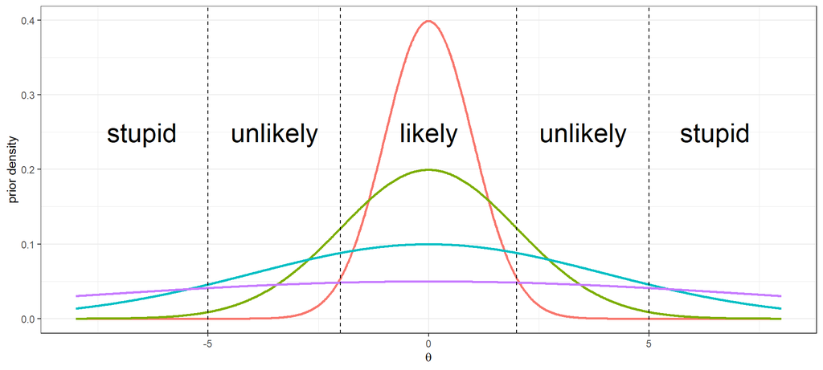

## Assigning a large prior variance is not being “uninformative”!

Suppose \(\theta\sim N(0,s_\theta^2)\)

- Likely range is \(|\theta|\leq 2\)
- Unlikely range is \(2<|\theta|\leq 5\)
- Stupid range is \(|\theta|>5\)

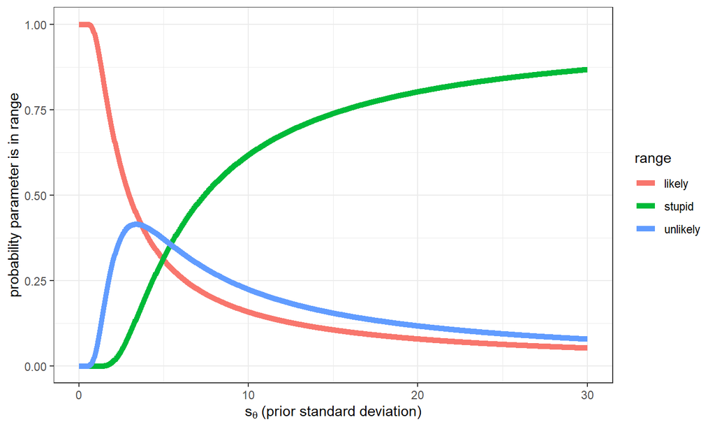

## Coming up with some meaningful ranges

E.g. Holt and Laury (2002) with \(r\sim N(0.27,s_r^2)\), from Bland (2023a):

Distribution across risk preference categories

| range | classification | Holt and Laury (2002) | Prior standard deviation \(s_r\) 0.36 | Prior standard deviation \(s_r\) 3.6 | Prior standard deviation \(s_r\) 36 |
| --- | --- | --- | --- | --- | --- |
| r<-0.95 | highly risk loving | 0.01 | 0.00 | 0.37 | 0.49 |
| -0.95<r<-0.49 | very risk loving | 0.01 | 0.02 | 0.05 | 0.01 |
| -0.49<r<-0.15 | risk loving | 0.06 | 0.10 | 0.04 | 0.00 |
| -0.15<r<0.15 | risk neutral | 0.26 | 0.25 | 0.03 | 0.00 |
| 0.15<r<0.41 | slightly risk averse | 0.26 | 0.28 | 0.03 | 0.00 |
| 0.41<r<0.68 | risk averse | 0.23 | 0.22 | 0.03 | 0.00 |
| 0.68<r<0.97 | very risk averse | 0.13 | 0.10 | 0.03 | 0.00 |
| 0.97<r<1.37 | highly risk averse | 0.03 | 0.02 | 0.04 | 0.00 |
| 1.37<r | stay in bed | 0.01 | 0.00 | 0.38 | 0.49 |

## But sometimes conceptualizing a parameter is difficult

For example: \(\lambda\)

- “choice precision”
- What does that even mean?
- What does a doubling of \(\lambda\) mean?
- Units: inverse utility (hard to interpret)

**Alternative approach:** What do different realizations of this parameter mean about *predictions* in our experiment?

What are plausible and implausible *predictions*?

## How do predictions change with \(\lambda\)

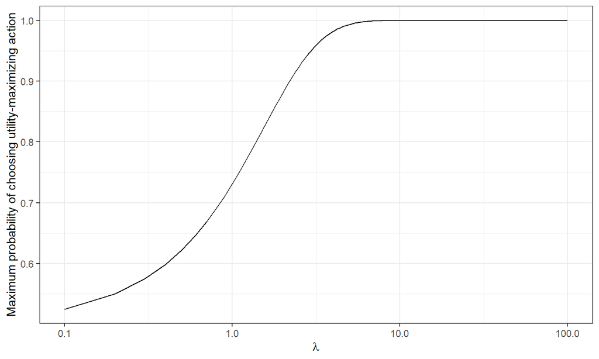

## How do predictions change with \(\lambda?\)

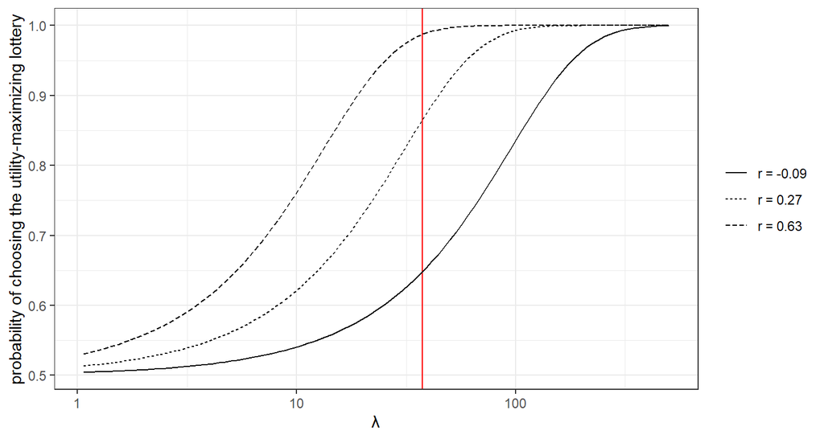

\(L\): $30 for sure

\(R\): a 50-50 mix of $10 and $50

## Calibration for \(\lambda\)

All of the interesting variation happens for \(\lambda\in(10,100)\). Use this to pin down a 95% prior credible region:

\[ \begin{aligned} \log 100 &=m_\lambda +1.96 s_\lambda\\ \log 10 &=m_\lambda -1.96 s_\lambda\\ \implies m_\lambda &\approx 3.45,\quad s_\lambda\approx 0.59 \end{aligned} \]

## Implementation

Estimating one model for each of the 175 participants

*Stan* code: `CRRAindividual.stan`

*R* code: `Estimate.R`

## Estimates – posterior means

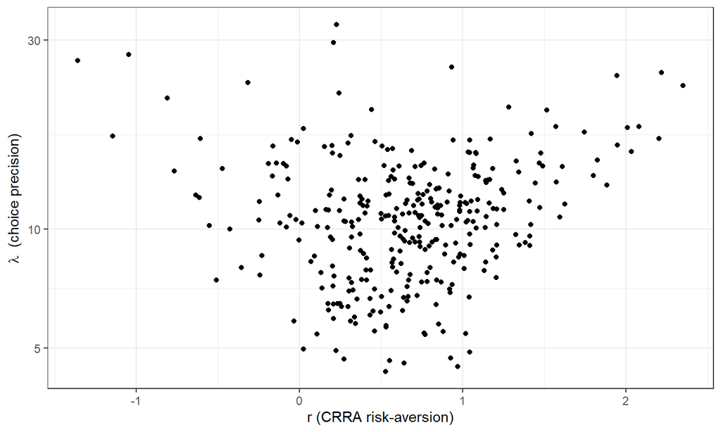

## Estimates – \(r\)

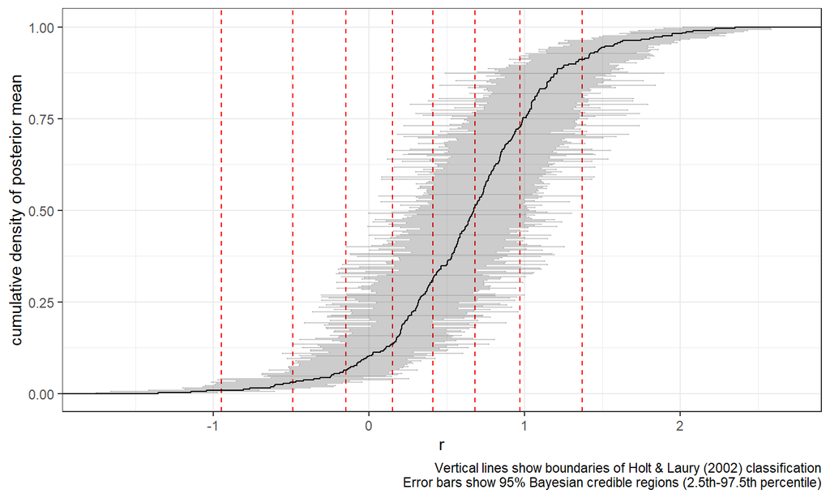

## Estimates – \(\lambda\)

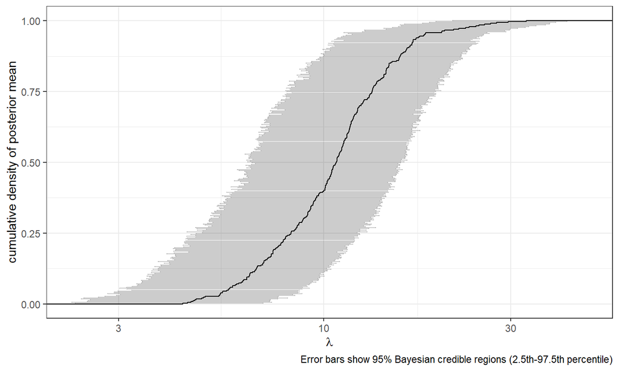

## How much did we learn?

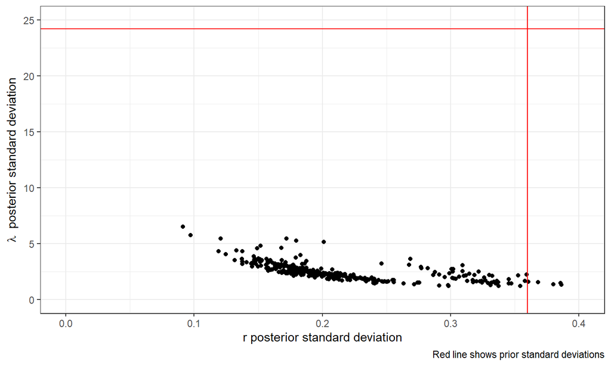

## Doing something with the estimates

We have estimated the parameters of the economic model!

Really, we have \(S\) draws from the posterior distribution \(\{r_s,\lambda_s\}_{s=1}^S\), and reported *summary statistics* of these draws.

**Functions** of the model’s parameters may:

- Be easier to interpret
- Be of more interest
- Answer different research questions

## Functions of parameters are **very** easy to simulate!

Once we have \(\{r_s,\lambda_s\}_{s=1}^S\), it is very easy to compute:

\[ \left\{f(r_s,\lambda_s)\right\}_{s=1}^S \]

Can be done outside of *Stan* using `extract`

Done within *Stan* in the `generated quantities` block:

- Compute functions of data and parameters
- Not used in computing the posterior density – Fast!

## Functions of the parameters for this EUT model

Given \(r\) and \(\lambda\), we can calculate a:

- **Certainty equivalent** for lottery \(L\):
  - Certain amount of money \(\$c\) such that \(c\sim L\)
- **Choice probability:**
  - For lotteries \(L\) and \(R\), what is the probability that \(L\) is chosen?
- **Cost of probabilistic choice** (if we take the model very seriously):
  - Not necessarily a mistake – cognitive costs, mis-specified model, etc
  - Similar application to Alekseev et al. (2018)

## Certainty equivalent

Lottery \(L\): a 50/50 mixture of $10 and $50

\[ \begin{aligned} \frac{c^{1-r}}{1-r}&=0.5\frac{10^{1-r}}{1-r}+0.5\frac{50^{1-r}}{1-r}\\ c&=\left(0.5\times 10^{1-r}+0.5\times 50^{1-r}\right)^\frac{1}{1-r} \end{aligned} \]

## Choice probability

Lottery \(L\): a 50/50 mixture of $10 and $50

Lottery \(R\): $30 for sure

\[ \begin{aligned} p(L)&=\Lambda\left[\lambda\left(\frac{0.5\frac{10^{1-r}}{1-r}+0.5\frac{50^{1-r}}{1-r}-\frac{30^{1-r}}{1-r}}{\frac{50^{1-r}}{1-r}-\frac{10^{1-r}}{1-r}}\right)\right]\\ &=\Lambda\left[\lambda\left(\frac{0.5\times 10^{1-r}+0.5\times 50^{1-r}-30^{1-r}}{50^{1-r}-10^{1-r}}\right)\right]\\ ~\\ \Lambda(x)&=(1+\exp(-x))^{-1} \end{aligned} \]

## Cost of probabilistic choice

Lottery \(L\): a 50/50 mixture of $10 and $50

Lottery \(R\): $30 for sure

Express as a difference in certainty equivalents

\[ \begin{aligned} C&^\text{no noise}-C^\text{noise}\\ &=\left((1-r)\max\{U(L),U(R)\}\right)^\frac{1}{1-r}\\ &\quad - \left[(1-r)\left(p(L)U(L)-(1-p(L))U(R)\right)\right]^\frac{1}{1-r} \end{aligned} \]

## Implementation

See `generated quantities` block of `CRRAindividual.stan`

## Certainty equivalent

Lottery \(L\): a 50/50 mixture of $10 and $50

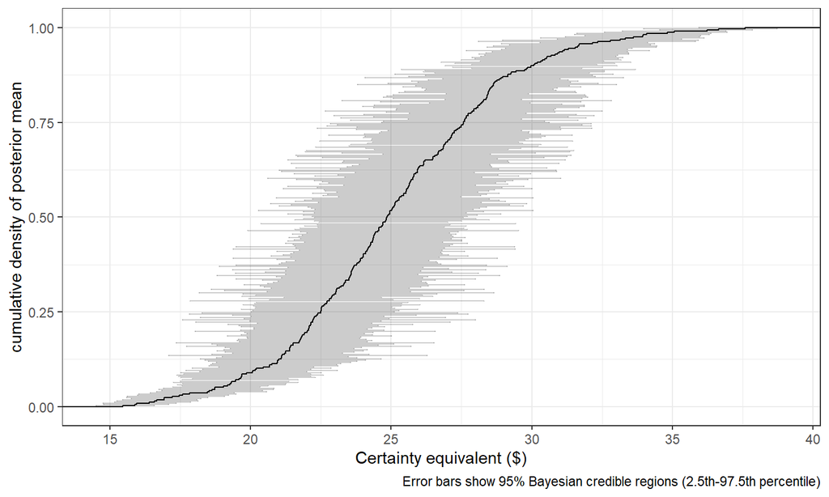

## Choice probability

Lottery \(L\): a 50/50 mixture of $10 and $50

Lottery \(R\): $30 for sure

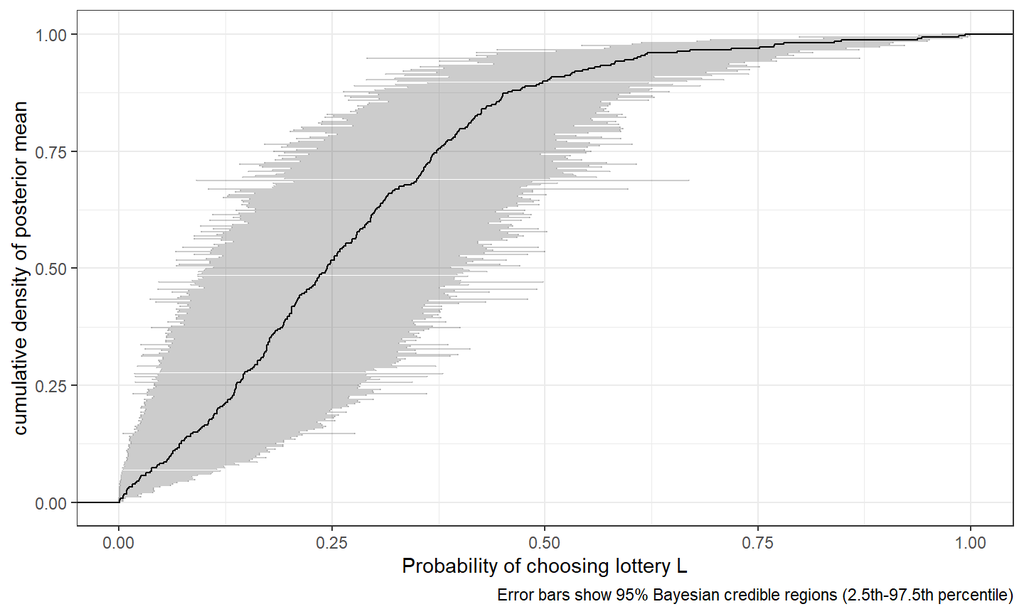

## Cost of probabilistic choice

Lottery \(L\): a 50/50 mixture of $10 and $50

Lottery \(R\): $30 for sure

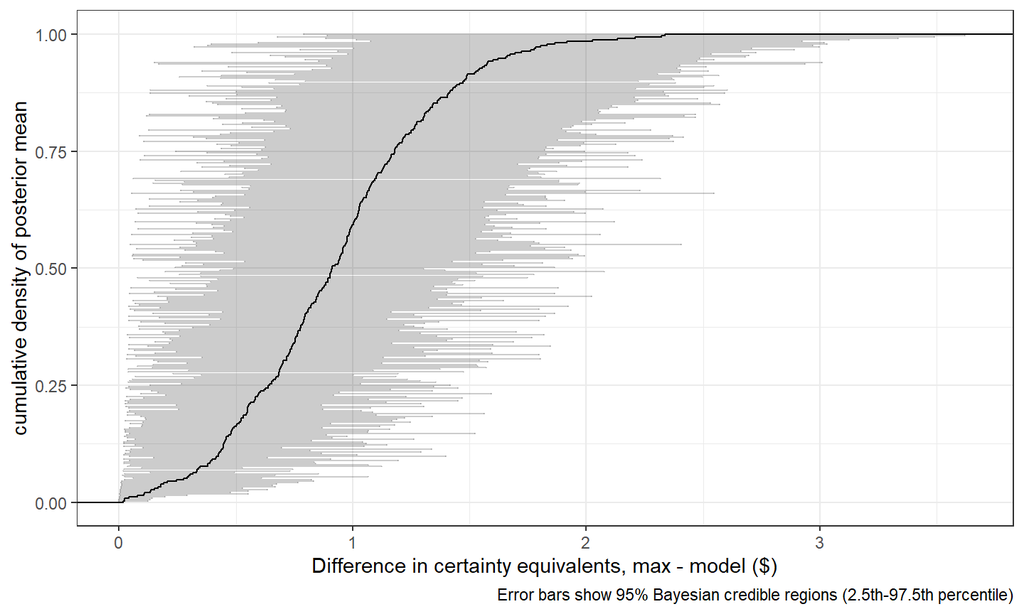

## Recap

Estimated a model using data from experiment

- Assumption about model: EUT
- Assumption about utility: CRRA
- Assumption about probabilistic choice: logit

One model for each participant

- Could have also estimated a representative agent model with the same procedure

A model of behavior of an **individual** in a **non-strategic** environment

Next steps: Strategic settings and heterogeneity

## Equilibrium in games

## In economics, we don’t *just* optimize

**Equilibrium:** what happens when everyone optimizes at the same time?

For this section: focus on equilibrium in *games* (not markets)

Computational techniques:

- Dealing with conditions defined by a fixed point
- Similar treatment in Bayesian and MLE approaches

## Beliefs in games

In the EUT example: exogenous probabilities associated with lotteries

In games, we need:

- A model for how players choose actions **given their beliefs** about opponents’ strategies
  - Nothing new here
- A model of how players **form beliefs** about opponents’ strategies
  - The new part

## Various kinds of models for beliefs in games

(not exhaustive)

Similar challenges to individual decision-making problems:

- **Learning:** Beliefs are a function of game history
- **Introspection:** Beliefs are endogenous, iterative solution

A whole new can of worms:

- **Equilibrium:** Beliefs are endogenous, fixed point

## The problem with equilibrium models

They have a lot of appeal, but equilibrium conditions often look like this:

\[ \sigma = F(\sigma),\quad \text{or worse,}\quad \sigma\in F(\sigma) \]

where \(\sigma\) is a mixed strategy profile.

- \(\sigma\) appears on both the LHS and the RHS of the equation
- A fixed point problem
- Typically cannot be solved with iteration (i.e. assuming a contraction)
- Multiple solutions may exist

Big problem for us: **slow** and **unstable** to solve, and we need to solve it **thousands** of times!

## Example experiment: Goeree, Holt, and Smith (2017)

**The Volunteer’s Dilemma**

|  | At least one other player volunteers | Nobody else volunteers |
| --- | --- | --- |
| Volunteer | V-c | V-c |
| Not volunteer | V | L |

- \(V=1\), \(L=c=0.2\) constant for all treatments
- Vary group size \(n= 2,\ 3,\ 6,\ 9,\ 12\)
- 20 rounds played

## Data

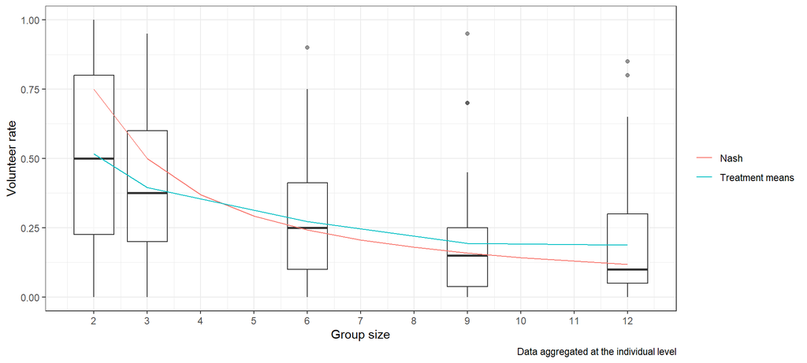

## Some observations

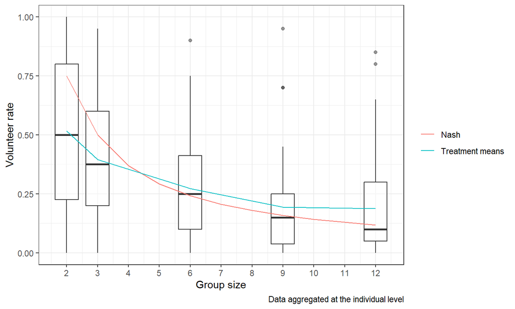

- Deviations from Nash prediction. On average and individually
- Heterogeneity in choice frequencies

## A model for equilibrium

**Quantal response equilibrium** (McKelvey and Palfrey 1995):

- Players noisily respond to their beliefs about opponents’ mixed strategies
  - More **behaviorally plausible** than Nash
  - Avoids the zero likelihood problem of Nash and dominated strategies
- Beliefs are consistent

Using the logit response specification:

\[ \sigma_{i,j}=\frac{\exp(\lambda u_{i,j}(\sigma))}{\sum_k \exp(\lambda u_{i,k}(\sigma))} \]

## A simplifying assumption

**Symmetry:** All players volunteer with the same probability.

We will relax this later with a behavioral extension

## Things we can do with a QRE model and some data

- **Estimate** choice precision \(\lambda\)
- **Predict** play in another treatment, e.g.
  - Different group sizes
  - Different payoff parameters
- **Compare** predicted behavior to observed behavior

## Some tips for solving QRE

\[ \sigma_{i,j}=\frac{\exp(\lambda u_{i,j}(\sigma))}{\sum_k \exp(\lambda u_{i,k}(\sigma))} \]

This will likely be the bulk of your computational burden. Estimation once this is done is relatively fast.

For all but the simplest problems, **don’t**

- Treat it as a contraction (it probably is not one)
- Use in-built equation solvers (you can do better)
- Solve the system in probability levels (it is more stable in log or logit form)

**Do** consider using the predictor-corrector algorithm (Turocy 2010)

- Discussed in Bland and Turocy (2023)
- Implemented in *Gambit* (McKelvey, McLennan, and Turocy 2022)

## Fast(-ish) QRE Part 1: logs are your friend

\[ \sigma_{i,j}=\frac{\exp(\lambda u_{i,j}(\sigma))}{\sum_k \exp(\lambda u_{i,k}(\sigma))} \]

Let \(\rho_{i,j}=\log\sigma_{i,j}\)

Equilibrium conditions:

\[ \begin{aligned} 0&=\rho_{i,j+1}-\rho_{i,j}-\lambda\left[u_{i,j+1}(\rho)-u_{i,j}(\rho)\right]\quad \forall i,\ \forall j\in 1, 2, J_i-1 \end{aligned} \]

Adding-up conditions:

\[ \begin{aligned} 0&=\sum_{j=1}^{J_i}\exp(\rho_{i,j})-1 \end{aligned} \]

Stack these into a function \(H(\rho,\lambda)=0\)

## Fast(-ish) QRE Part 1: logs are your friend (continued)

To estimate a model, you will need to compute the log-likelihood of your model (and combine it with a prior).

The log equilibrium mixed strategies are exactly what you need to do this!

\[ \log p(y\mid \lambda)= y^\top \rho(\lambda) \]

\[ \log p(\lambda , y)=y^\top \rho(\lambda)+\log p(\lambda) \]

where \(y_{i,j}\) is the number of times player \(i\) chose action \(j\).

## Fast(-ish) QRE Part 2: Use the derivatives

\[ H(\rho,\lambda)=0 \]

The predictor-corrector algorithm uses information in \(\frac{\partial H(\rho,\lambda)}{\partial \rho^\top}\) and \(\frac{\partial H(\rho,\lambda)}{\partial \lambda}\) to make approximations of the system.

**Predictor step:** Starting from a known solution \((\rho,\lambda)\), use the derivatives to make a linear approximation of a new solution \((\rho',\lambda')\)

**Corrector step:** Use derivatives and the zero conditions to correct any errors the approximation may have introduced.

## Setting up the system for the Volunteer’s dilemma

Equilibrium condition:

\[ 0=\rho_V-\rho_N-\lambda\left[V-c-V(1-\exp(\rho_N)^{n-1})-L\exp(\rho_N)^{n-1}\right] \]

Adding-up condition:

\[ 0=\exp(\rho_V)+\exp(\rho_N)-1 \]

So:

\[ H(\rho,\lambda)=\begin{pmatrix} \rho_V-\rho_N-\lambda\left[V-c-V(1-\exp(\rho_N)^{n-1})-L\exp(\rho_N)^{n-1}\right]\\ \exp(\rho_V)+\exp(\rho_N)-1 \end{pmatrix} \]

## An even faster way to solve this

Make the problem 1-dimesional. Let \(\ell = \log (\sigma_V)-\log(1-\sigma_V)\)

\[ H(\ell,\lambda)=\ell-\lambda\left[V-c-V(1-\Lambda(-\ell)^{n-1})-L\Lambda(-\ell)^{n-1}\right] \] \[ \begin{aligned} \frac{\partial H(\ell,\lambda)}{\partial \ell} &=1+\lambda \Lambda'(\ell)(V-L)(n-1)\Lambda(-\ell)^{n-2}\\ ~\\ \text{where }\Lambda(x)&=(1+\exp(-x))^{-1}\\ \Lambda'(x)&=\Lambda(x)(1-\Lambda(x))=\Lambda(x)\Lambda(-x) \end{aligned} \]

## Constant-\(\lambda\) corrector steps

\[ \ell^{t+1}=\ell^t-\frac{H(\ell^t,\lambda)}{\frac{\partial H(\ell^t,\lambda)}{\partial \ell}} \]

Keep iterating until \(|\ell^{t+1}-\ell^t|<\epsilon\)

## Implementation

*Stan* file: `VDQREhomogeneous_CorrectorLogit.stan`

*R* file: `QREVD.R`

## Results

|  | mean | sd | 2.5% | 25% | 50% | 75% | 97.5% |
| --- | --- | --- | --- | --- | --- | --- | --- |
| λ | 11.16 | 1.21 | 9.06 | 10.33 | 11.07 | 11.91 | 13.75 |
| n=2 | 0.67 | 0.01 | 0.66 | 0.67 | 0.67 | 0.67 | 0.68 |
| n=3 | 0.50 | 0.00 | 0.50 | 0.50 | 0.50 | 0.50 | 0.50 |
| n=6 | 0.31 | 0.01 | 0.30 | 0.30 | 0.31 | 0.31 | 0.32 |
| n=9 | 0.24 | 0.01 | 0.22 | 0.23 | 0.24 | 0.24 | 0.25 |
| n=12 | 0.20 | 0.01 | 0.18 | 0.19 | 0.20 | 0.20 | 0.21 |
| lp__ | -2393.35 | 0.75 | -2395.53 | -2393.53 | -2393.06 | -2392.88 | -2392.82 |

## Predictions and data

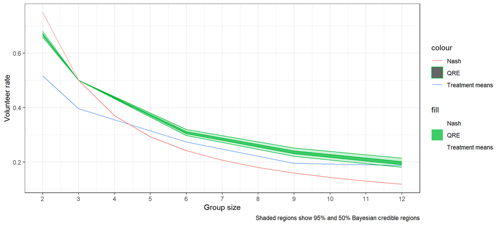

## Hierarchical models

## Participants are heterogeneous!

**Experimenter-induced heterogeneity:** We may have assigned players different roles in a game.

- We **control** this kind of heterogeneity

**Observable participant characteristics:**

- E.g. demographics collected in a survey

**Unobservable participant characteristics:**

- We don’t observe these things, but we can structurally **estimate** them
- E.g. risk, time, other-regarding preferences

Here we will worry about the third kind

## Why you should care about heterogeneity

**Heterogeneity might be interesting in itself.** Estimating a model assuming no heterogeneity denies you this information.

**Pooled models will overstate the confidence you should have in your estimates:** If \(N\) participants make \(T\) decisions each, you don’t have \(N\times T\) independent observations.

**Heterogeneity bias.** Even if you don’t care about heterogeneity, assuming participants are homogeneous can produce misleading results.

- Nuisance parameters
- See Wilcox (2006) for an example using learning models

## But individual-level estimation can also be a problem

**Solution???** Estimate one model per participant

- Might not have enough observations to do this meaningfully
- Not a clear way to organize the data as a whole
- Not clear what we would be doing if there is an equilibrium condition

**Hierarchical models:** Assume that participants are random draws from a population, estimate the parameters governing the population distribution.

## A basic hierarchical model

\(\theta_i\): parameters describing participant \(i\)’s behavior

- \(r_i\) and \(\lambda_i\) in the EUT model

\(\Theta\): parameters describing the distribution of \(\theta_i\) in the population

\[ \theta_i \sim iid \mathcal{F}(\Theta) \]

Almost all applications in the literature assume a multivariate normal specification:

\[ \theta_i\sim iid N(\mu,\Sigma) \]

## What can we do with hierarchical models?

\[ \theta_i\sim iid N(\mu,\Sigma) \]

- Model heterogeneity that we suspect is present
- Quantify the extent of this heterogeneity (i.e. interpret \(\Sigma\))
- Get participant-specific estimates of \(\theta_i\) that leverage the entire dataset
- Calculate economically meaningful quantities that are functions of the individual-level parameters and/or population-level parameters.

## The math behind hierarchical models

Suppose we want to estimate the population-level parameters \(\mu\) and \(\Sigma\)

\[ \begin{aligned} p(\mu,\Sigma\mid y)&\propto p(y\mid \mu,\Sigma)\ p(\mu,\Sigma) \\ &=\int p(y,\theta\mid \mu,\Sigma)\mathrm d\theta\ p(\mu,\Sigma)\\ &=\int p(y\mid \theta,\mu,\Sigma)p(\theta\mid \mu,\Sigma)\mathrm d\theta \ p(\mu,\Sigma)\\ &=\int p(y\mid \theta)p(\theta\mid \mu,\Sigma)\mathrm d\theta \ p(\mu,\Sigma) \end{aligned} \]

- Similar to MLE approach – integrate the likelihood (with simulation)

However modern Bayesian techniques (especially HMC) do better when we use **data augmentation** …

## Data augmentation in hierarchical models

**Jointly estimate** the individual-level and population-level parameters

\[ \begin{aligned} p(\theta,\mu,\Sigma\mid y)&\propto p(y\mid \theta,\mu,\Sigma)\ p(\theta,\mu,\Sigma)\\ &=p(y\mid \theta)\ p(\theta\mid \mu,\Sigma)\ p(\mu,\Sigma) \end{aligned} \]

\(p(y\mid \theta)\): individual likelihood contributions

\(p(\theta\mid \mu,\Sigma)\): “prior” for individual-level parameters

- We don’t need to specify this, as it is determined by \((\mu,\Sigma)\)

\(p(\mu,\Sigma)\): prior for population-level parameters

- This is the prior we need to specify.

## Data augmentation in *Stan*

```c
parameters {
  matrix[k,n] theta;
  vector[k] mu;
  corr_matrix[k] Omega;
  vector<lower=0>[k] Tau;
}

model {
  // put some code here that adds the likelihood to the target

  matrix[k,k] Sigma = quad_form_diag(Omega, Tau);
  // hierarchical structure ("prior" for theta)
  theta ~ multivariate_normal(mu,Sigma);
  // priors
  Omega ~ lkj_corr(4.0); // (prior for Omega)
  Tau ~ cauchy(0.0,1.0); // (prior for Tau)
}
```

## Example: Back to the Volunteer’s Dilemma

**Warm glow volunteering:** Participants receive bonus utility \(\theta_i\) from volunteering

**Duplicate aversion:** Participants suffer loss \(\theta_i\) if they volunteer unnecessarily

In both cases, assume that:

\[ \theta_i \sim iid\ \mathrm{Truncated\ Normal}(\mu,\tau^2,(\mu-\tau,\mu+\tau)) \]

- Goeree, Holt, and Smith (2017) assume a discretized version of this
- Allowing much more spread than \(\mu \pm \tau\) results in dividing by something close to zero

## How these extensions affect utility

Let \(\bar\sigma_V =\) average probability that a player volunteers

**Warm glow:**

\[ u_V(\bar\sigma_V,\theta_i)=V-c+\theta_i \]

**Duplicate aversion:** \[ u_V(\bar\sigma_V,\theta_i)=V-c-\theta_i\left(1-(1-\bar\sigma_V)^{n-1}\right) \]

Utility of not volunteering is unchanged:

\[ u_N(\bar\sigma_V,\theta_i)=V\left(1-(1-\bar\sigma_V)^{n-1}\right)+L(1-\bar\sigma_V)^{n-1} \]

## A complication

**The equilibrium condition!** We now have a Bayesian game.

\[ \begin{aligned} \bar \sigma_V&=E_\theta\left[\frac{\exp(\lambda u_V(\bar\sigma_V,\theta))}{\exp(\lambda u_V(\bar\sigma_V,\theta))+\exp(\lambda u_N(\bar\sigma_V,\theta))}\right]\\ &=E_\theta\left[\Lambda\left(\lambda\left(u_V(\bar\sigma_V,\theta)-u_N(\bar\sigma_V,\theta)\right)\right)\right] \end{aligned} \]

We can solve this approximately with Monte Carlo integration:

\[ \bar \sigma_V\approx \frac1S\sum_{s=1}^S\Lambda\left(\lambda\left(u_V(\bar\sigma_V,\theta_s)-u_N(\bar\sigma_V,\theta_s)\right)\right) \]

**Why this works:** I only care about the probability my opponents volunteer, not their preferences.

## Setting up a stable system to solve

Let \(\bar l = \log(\bar\sigma_V)-\log(1-\bar\sigma_V)\)

\[ \begin{aligned} 0=H(\bar\ell,\lambda)&=\bar\ell-\log\left(\frac1S\sum_{s=1}^S\Lambda\left(\lambda\left(u_V(\bar\sigma_V,\theta_s)-u_N(\bar\sigma_V,\theta_s)\right)\right)\right)\\ &\quad \quad+\log\left(\frac1S\sum_{s=1}^S\left[1-\Lambda\left(\lambda\left(u_V(\bar\sigma_V,\theta_s)-u_N(\bar\sigma_V,\theta_s)\right)\right)\right]\right) \end{aligned} \]

Then iterate on:

\[ \bar\ell^{t+1}=\bar\ell^t-\frac{H(\bar\ell^t,\lambda)}{\frac{\partial H(\bar\ell^t,\lambda)}{\partial \bar\ell}} \]

## Implementation

Warm glow: `VDQREwarmglow.stan`

Duplicate aversion `VDQREduplicateaversion.stan`

*R* script `QREVD.R`

## Results – population-level estimates

Posterior means with posterior standard deviations in parentheses

|  | Homogeneous | Warm glow | Duplicate aversion | Data |
| --- | --- | --- | --- | --- |
| λ | 11.16 (1.21) | 6.1 (1.69) | 9.84 (2.86) |  |
| n=2 | 0.67 (0.01) | 0.51 (0.04) | 0.56 (0.03) | 0.52 |
| n=3 | 0.5 (0) | 0.41 (0.02) | 0.41 (0.02) | 0.4 |
| n=6 | 0.31 (0.01) | 0.29 (0.02) | 0.26 (0.02) | 0.27 |
| n=9 | 0.24 (0.01) | 0.24 (0.02) | 0.2 (0.02) | 0.19 |
| n=12 | 0.2 (0.01) | 0.22 (0.02) | 0.17 (0.02) | 0.19 |
| μ |  | -0.19 (0.07) | 0.21 (0.07) |  |
| τ |  | 0.52 (0.15) | 0.46 (0.13) |  |

## Can we do anything with all of the augmented data?

Recall, we drew from the posterior:

\[ \theta,\lambda ,\mu,\tau \mid y \]

Up to this point, we have interpreted the population parameters \(\lambda\), \(\mu\), and \(\tau\), and some predictions implied by them.

We also have the \(\theta\)s, which are the augmented data.

## Interpretation of the augmented data

Consider the draws for just one participant’s parameter \(\theta_i\).

These are draws from \(\theta_i\mid y\)

- Conditioning on **both** \(y_i\) and \(y_{-i}\)

> What do *all* of the data tell us about \(\theta_i\)?
- \(y_i\) tells us something about \(\theta_i\) because \(i\) made these decisions
- \(y_{-i}\) also tells us something:
  - What are appropriate values for \(\mu\) and \(\tau\)?
  - Knowing things about the population is useful in knowing something about an individual participant

## Warm glow individual-level parameters

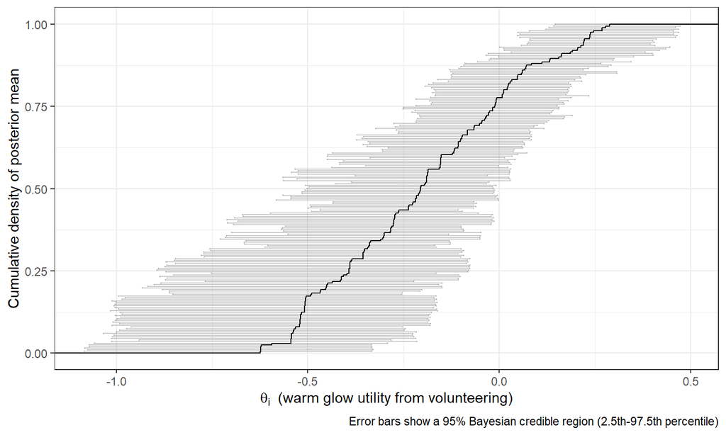

## Duplicate aversion individual-level parameters

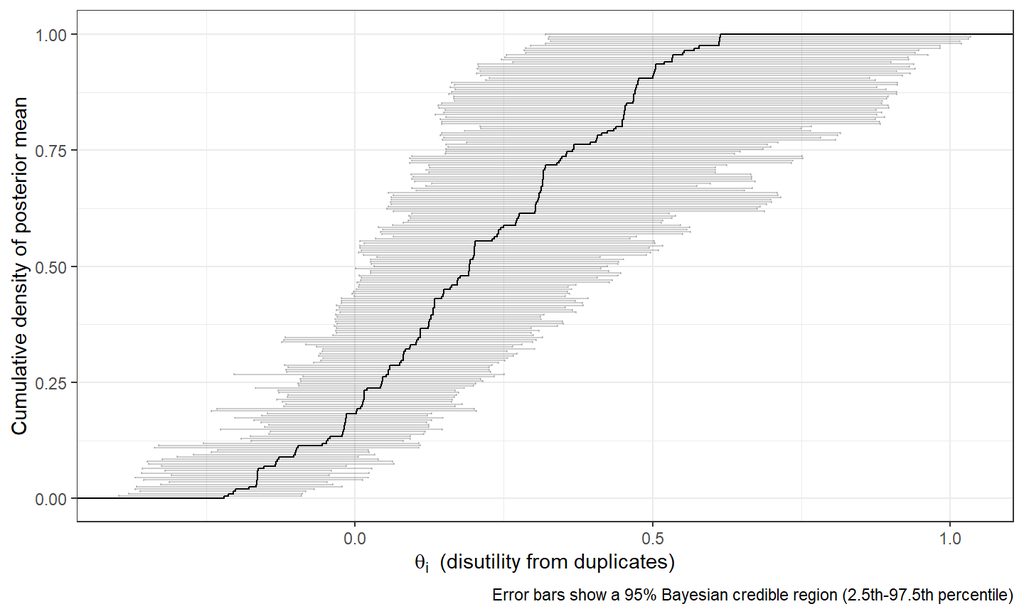

## But now we have **three** models!

## We estimated three QRE models

1. Homogeneous
2. Warm glow volunteering
3. Duplicate aversion

Which one should we take the most seriously?

As with other things, we treat this **probabilistically**.

## Posterior probability of a model

\[ p(A\mid B)\propto p(B\mid A)p(A) \]

Re-label some parts of Bayes’ rule again:

\[ p(\mathrm{model}\mid y)\propto p(y\mid \mathrm{model})p(\mathrm{model}) \]

\(p(y\mid \mathrm{model})\): The “marginal likelihood” from:

\[ p(\theta\mid y, \mathrm{model})=\frac{p(y\mid \theta,\mathrm{model})p(\theta\mid \mathrm{model})}{p(y\mid \mathrm{model})} \]

When we were just estimating one model, we left out “\(\mathrm{model}\)” in our notation, but it is implicitly there.

Can be done in *R* using the `bridgesampling` library

## Model posterior probabilities

prior: each model is equally likely

```
##       homogeneous duplicateaversion          warmglow
##     7.018994e-228      6.415276e-06      9.999936e-01
```

## Finite mixtures (if time permits)

## Discrete vs. continuous heterogeneity

Hierarchical models: heterogeneous parameters are **continuous** random variables

Sometimes we also need to add **discrete** heterogeneity to our models

- Expected utility theory or prospect theory
- Broad or narrow bracketing
- Level-\(k\) thinking (\(k\) is discrete)
- Strategies used in an indefinitely repeated game

## Discrete heterogeneity and types

Suppose we have types indexed by \(\tau\).

Each type specifies a different likelihood function:

\[ p(y\mid \theta,\tau) \]

“What would the data look like if it was generated by only type \(\tau\)?”

## Mixing probabilities

Each type \(\tau\) has a **mixing probability** \(\psi_\tau\)

- The probability that a chunk of data is generated by type \(\tau\)
  - Participants, e.g. Conte, Hey, and Moffatt (2011)
  - Individual decisions, e.g. Harrison and Rutström (2009)

These are often the quantities we are most interested in!

The fraction of participants who:

- Use the EUT model
- Are selfish
- Play “Always defect” in an indefinitely repeated Prisoner’s Dilemma
- Bracket decisions narrowly

## A *Stan*-specific problem

*Stan* can only deal with continuous parameters, so we can’t augment the data by \(\tau\)

Instead, to compute the likelihood, we integrate it out:

\[ p(y\mid\theta)=\sum_{\tau}\psi_\tau p(y\mid \theta,\tau)=E_\tau[p(y\mid \tau,\theta)] \]

See the appendix of the working paper version of Bland (2020) for an example of the the data-augmentation approach using a Gibbs sampler: https://papers.ssrn.com/sol3/papers.cfm?abstract_id=3324606

## More on integrating out types

We need to add the *log* likelihood to the `target`:

\[ \begin{aligned} \log p(y_i\mid\theta)&=\log\left(\sum_{\tau}\psi_\tau p(y_i\mid \theta,\tau)\right)\\ &=\log\left(\sum_\tau\psi_\tau\exp\left(\log p(y_i\mid\theta,\tau)\right) \right) \\ &=\log\left(\sum_\tau\exp\left(\log \psi_\tau+ \log p(y_i\mid\theta,\tau)\right) \right) \end{aligned} \]

now we can use `log_sum_exp()`

## Example: Dal Bó and Fréchette (2011)

Indefinitely repeated Prisoner’s Dilemma

|  | \(C\) | \(D\) |
| --- | --- | --- |
| \(C\) | \(R\), \(R\) | \(12\), \(50\) |
| \(D\) | \(50\), \(12\) | \(25\), \(25\) |

Treatments:

- Discount factor \(\delta\in\{\frac12,\ \frac34\}\)
- Payoff from cooperating: \(R\in\{32,\ 40,\ 48\}\)

Data used: Games that started after more than 110 interactions.

## Strategy frequency estimation

Assume that every player is using exactly one of a given list of strategies:

1. Always Defect (AD)
2. Always Cooperate (AC)
3. Grim Trigger (G), defect for ever once one person has defected
4. Tit for Tat (TFT)
5. Win Stay Lose Shit (WSLS)
6. Tit for two tats (T2)

Estimate the fraction of participants who use each strategy

## Some notation

- \(y_{i,\tau} =\) the number of times participant \(i\) chose consistently with strategy \(\tau\)
- \(n_{i} =\) the total number of decisions participant \(i\) made

## The (usual) problem with likelihoods

**Problem:** All of these strategies are deterministic

**Solution:** Add in a tremble \(\gamma\in(0,\ 0.5)\)

\[ p(y_{i,\tau}\mid \gamma, n_i,\tau)= (1-\gamma)^{y_{i,\tau}}\gamma^{n_i-y_{i,\tau}} \]

## Implementation

\[ \begin{aligned} \psi&\sim\mathrm{Dirichlet}(1,1,1,1,1,1)\\ \gamma&\sim\mathrm{Truncated\ Beta}(1,1,(0,0.5)) \end{aligned} \]

*Stan* file: `SFEMhomogeneous.stan`

- Note the use of `log_sum_exp()`

*R* code: `SFEM.R`

## Results

| \(\delta\) \(R\) | 0.5 32 | 0.5 40 | 0.5 48 | 0.75 32 | 0.75 40 | 0.75 48 |
| --- | --- | --- | --- | --- | --- | --- |
| AD | 0.83 (0.05) | 0.72 (0.06) | 0.49 (0.07) | 0.59 (0.07) | 0.12 (0.05) | 0.02 (0.02) |
| AC | 0.02 (0.02) | 0.08 (0.04) | 0.08 (0.04) | 0.02 (0.02) | 0.27 (0.09) | 0.11 (0.07) |
| Grim | 0.02 (0.02) | 0.05 (0.03) | 0.03 (0.03) | 0.03 (0.03) | 0.23 (0.09) | 0.15 (0.1) |
| TFT | 0.09 (0.04) | 0.11 (0.04) | 0.33 (0.07) | 0.31 (0.07) | 0.3 (0.11) | 0.46 (0.12) |
| WSLS | 0.02 (0.02) | 0.02 (0.02) | 0.04 (0.03) | 0.02 (0.02) | 0.04 (0.04) | 0.06 (0.05) |
| TF2T | 0.02 (0.02) | 0.02 (0.02) | 0.02 (0.02) | 0.02 (0.02) | 0.05 (0.05) | 0.21 (0.11) |
| \(\gamma\) | 0.06 (0.01) | 0.14 (0.01) | 0.09 (0.01) | 0.1 (0.01) | 0.09 (0.01) | 0.03 (0) |

## But … following some advice from my adviser

“*Never use a regression table in a presentation*”

- Tim Cason

## Results in graph form

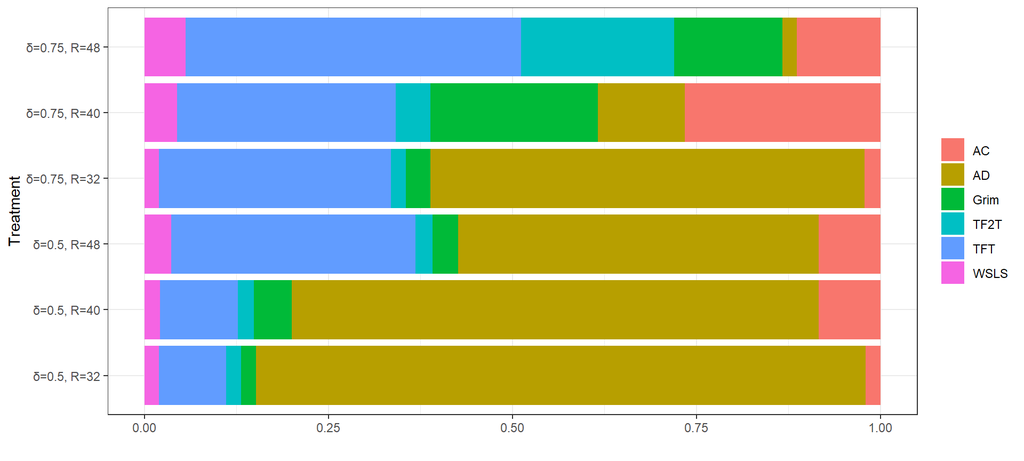

(This hides any expression of uncertainty in the estimates)

## An extension

Previous specification:

- Same likelihood as Dal Bó and Fréchette (2011)
- Just added priors and estimated using Bayesian techniques

But participants could be heterogeneous

- They use different strategies
  - The model already accounts for this
- They could tremble with different probabilities
  - We assumed that \(\gamma\) was homogeneous within a treatment

## Heterogeneous trembles – why should we care?

With SFEM, the goal is to estimate the mixing probabilities \(\psi\)

\(\gamma\) is a **nuisance parameter**:

- We don’t care directly about estimating it
- But we have to estimate it alongside \(\psi\)

**Heterogeneity bias:** If we assume a parameter is homogeneous when it isn’t, we can make misleading conclusions

E.g. Wilcox (2006):

- “… in the presence of parameter heterogeneity, pooled estimation can produce a severe bias that tends to unduly favor reinforcement learning relative to belief learning.” (from the abstract)
- Main culprit here is choice precision: a nuisance parameter

## A 1-parameter extension for heterogeneous trembles

\[ \begin{aligned} \gamma_i&=\frac12\Phi(\mu+z_i\sigma),\quad z_i\sim N(0,1) \end{aligned} \]

- \(\Phi(\cdot)\): standard normal cdf
- Transformation ensures that \(\gamma_i\in(0,0.5)\)

## Implementation

*Stan* file: `SFEMheterogeneous.stan`

*R* file: `SFEM.R`

Note the options used in calling *Stan*:

- `iter = 10000` (default \(=\) 2,000)
- `adapt_delta = 0.9999` (default \(=\) 0.8)

## Results

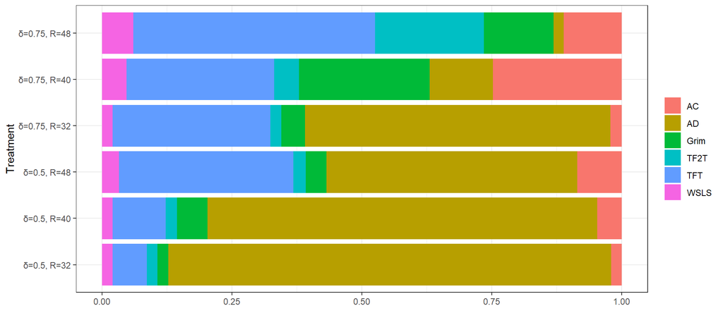

## Heterogeneous trembles

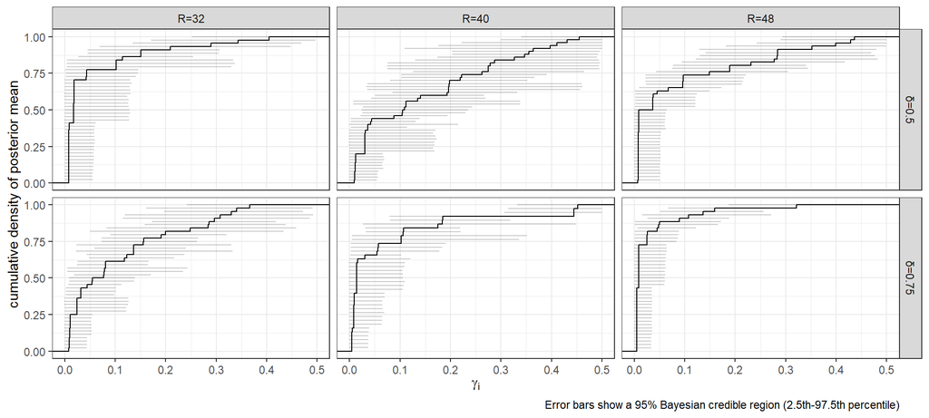

## Comparison to the homogeneous model

Not much difference, but we didn’t know that before trying this

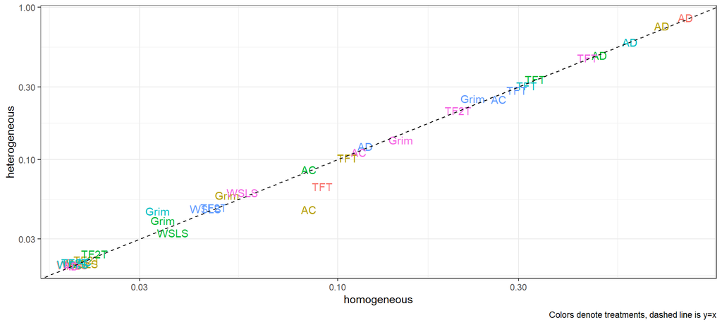

## Some other things you can do with strategy frequency estimation

- Test whether treatment variables have any impact on frequencies
  - E.g. test the restriction: discount factor has no impact on frequencies
- Distribution of trembles could vary by:
  - Treatment (as above)
  - Strategy
  - No variation
- Comment on the frequencies of types of strategies, e.g.:
  - Forgiving: can return to cooperation
  - Cooperative: start by playing \(C\)

## What is the appropriate specification for trembles?

**Heterogeneity:** present or not present?

**Which groups?** Same distribution within:

- a treatment (as before)
- a strategy
- the whole experiment

Six possible models to estimate

## A complication

For the model with heterogeneous trembles with strategy-specific distributions, data-augmentation is very unstable.

**Intuition:**

- Need to augment data for every participant-strategy pair, an \(N\times S\) matrix
  - Compared to \(N\times 1\) for treatment-specific distributions
- When \(\psi_\tau\approx0\) for a treatment, there is not much information about \(\gamma_{i,\tau}\).

**Solution:** Integrate the likelihood

## Integrating the likelihood (with simulation)

\[ \begin{aligned} p(y_{i,\tau}\mid \mu,\sigma)&=\int_0^{0.5}p(y_{i,\tau}\mid \gamma_{i,\tau})p(\gamma_{i,\tau}\mid \mu,\sigma)\mathrm d\gamma_{i,\tau}\\ &=E_{\gamma_{i,\tau}\mid \mu,\sigma}\left[p(y_{i,\tau}\mid \gamma_{i,\tau})\right]\\ &\approx\frac{1}{K}\sum_{k=1}^K p(y_{i,\tau}\mid \gamma_k)\\ ~\\ \gamma_k&=\frac12\Phi(\mu_\tau+z_k\sigma_\tau)\\ z_k&\sim iid N(0,1) \end{aligned} \]

Same approach used in simulated maximum likelihood

## Model posterior probabilities

| trembles within group | group | postprob |
| --- | --- | --- |
| homogeneous | experiment | 0.0000000 |
| homogeneous | treatment | 0.0000000 |
| homogeneous | strategy | 0.0000000 |
| heterogeneous | experiment | 0.9990577 |
| heterogeneous | treatment | 0.0000000 |
| heterogeneous | strategy | 0.0009423 |

## Selected model

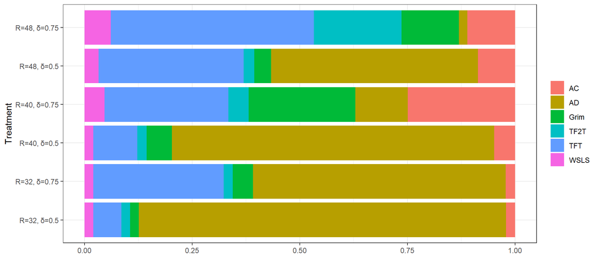

## Comparison to the usual specification

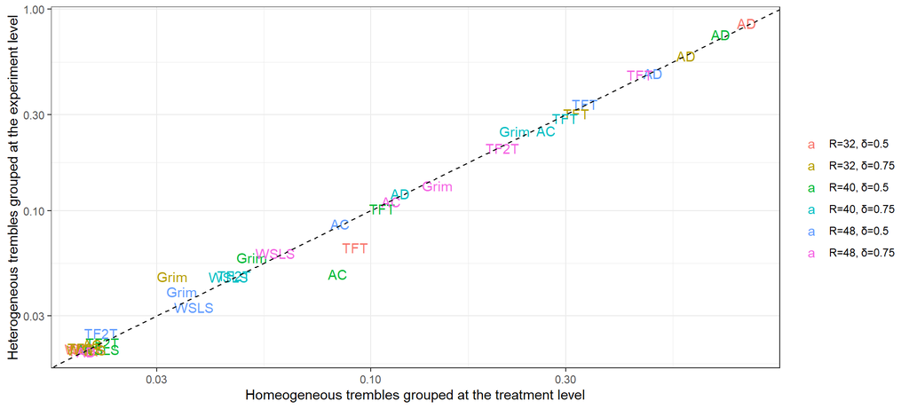

## Conclusion

## Big picture

I have a model (or models) and I want to:

- Estimate and comment on the parameters
- Comment on *transformations* of the parameters
- Comment on the importance of each model
- Assign a measure of uncertainty to all of the above

We have a framework for doing this

## Bayesian statistics

Applying Bayes’ rule to quantify posterior uncertainty in:

- Our model’s parameters

\[ p(\theta\mid y)\propto p(y\mid \theta) p(\theta) \]

- Assigning probabilities to models

\[ p(M\mid y)\propto p(y\mid M) p(M) \]

## The structural approach

**Estimate the parameters in the model**

- Interpret the parameters
- Interpret implications of the parameters, e.g.:
  - Predicted actions
  - Certainty equivalents

Compared to reduced-form:

- Compare differences in treatments,
- Draw a straight line through the data, interpret the slope

## Heterogeneity

Our participants are heterogeneous, and we should model this!

Bayesian techniques do this well

Some useful tools:

- Hierarchical models: Continuous types
  - Data augmentation
- Mixture models: Discrete types
  - Integrate the likelihood

Heterogeneity in a parameter could be important, even if you don’t care about that parameter!

## The econometrics of games

New concept compared to individual choice: **equilibrium**

Can be a fixed point problem

- Difficult and slow to solve
- Some tricks to help
  - compute in logs (stability)
  - predictor-corrector (using the derivatives)

## So when should I think about structural?

**Before running an experiment!**

- What parameters/quantities do I want to estimate?
- What might my data look like?
- Can I modify my experiment to better answer my research question?
- Will my experiment adequately estimate the models/quantities that I want it to?
- What kind of data (e.g. discrete or continuous) will make my estimation problem easier?

**After the experiment**

- To complement a traditional analysis (comparing treatments)
- Estimate economically meaningful quantities

## What are some things I should be thinking about when estimating structural models?

- How will this help **answer my research question**?
  - Economically meaningful quantities
  - Parameters/quantities that we can interpret
- What are the **underlying assumptions** of the model(s) I take to the data?
- Can I relax these assumptions?
  - More flexible functional forms
  - More parametric models (in mixture or separately)
- How am I accounting for **heterogeneity**?
  - Heterogeneity that I care about
  - Heterogeneity that I don’t care about but might affect my estimates

## What are some things to think about when doing **Bayesian** work?

- What do my priors say about:
  - Reasonable and unreasonable parameter values?
  - The data I might collect?
  - Economically meaningful quantities
  - The performance of my estimator?
- Data augmentation
  - Good for models with heterogeneity
  - In *Stan*: only continuous variables – integrate the likelihood for discrete heterogeneity

## What are some things to think about when implementing a model in *Stan*?

Data augmentation or integrate the likelihood?

Re-parameterizations

Efficient coding

- Know your bottlenecks!
- Pre-computing things
- Vectorized operations (avoiding `for` loops)

Parallelization: Between- and within-chain

## What should I think about when communicating my results?

Pictures really help

Try to communicate both:

- The point estimate (e.g. posterior mean), and
- An expression of uncertainty (e.g. 95% Bayesian credible region)

Beware of over-plotting when it comes to individual-level parameters

Make tables that look comforting to reduced-form frequentists:

- regression-like tables
- Posterior mean and standard deviation

## Placating the frequentists

Correspondence with the guest editor for the JESA special issue on “Statistical Issues for Experimental Economists”, December 2019

*… However, we feel that a Bayesian approach here is not appropriate for the Special Issue, particularly given the econometric sophistication of the readership and the difficulty of your problem. Your paper goes straight into a Bayesian analysis without stating why the Bayesian approach is preferable to the classical approach.*

Lessons learned:

- We still have to justify why we are not using frequentist techniques (although this is getting better)
- JESA readers lack “econometric sophisticiation”?

For the record, this problem was *much* easier to implement with Bayes

## Placating the frequentists

Stress the **practical** side of Bayesian estimation: it can turn a difficult maximization problem into a slightly less difficult simulation problem

- Especially for hierarchical models
- Expressions of uncertainty
  - Bayesian – part of the simulation
  - Frequentist – bootstrap or delta method
- **Show them what you can do with Bayes**

Show that you have thought about your priors.

- Have a good answer for why you chose them.
- Maybe do a prior sensitivity analysis

Last resort: capitulate. E.g. Bland (2020)

## Things not covered today but worth a look

Experiment design

- With the goal of estimating a structural model
- Using structural estimates
- E.g. Bland (2023b)

Model selection using cross-validation

- Not specific to Bayes
- Application to QRE here: Bland (2022)

Prior selection to avoid nasty posterior distributions

Within-chain parallelization in *Stan* (only if you have idle cores)

## Where are some datasets I can use to practice?

Experimental economics has really good data-sharing norms! If a paper is published, chances are you can get the data.

- Journal websites
- Authors’ websites, e.g:
  - Glenn Harrison: https://cear.gsu.edu/gwh/
  - Guillaume Frechette: http://people.cess.fas.nyu.edu/frechette/html/papers.htm
  - Peter Moffatt (Experimetrics online resources): https://www.bloomsburyonlineresources.com/experimetrics-econometrics
- Email people!

`james.bland@utoledo.edu`

## Thank you!

## References

Alekseev, Aleksandr, Glenn W Harrison, Morten Lau, and Don Ross. 2018. “Deciphering the Noise: The Welfare Costs of Noisy Behavior.”

Bland, James R. 2019. “How Many Games Are We Playing? An Experimental Analysis of Choice Bracketing in Games.” *Journal of Behavioral and Experimental Economics* 80: 80–91. https://doi.org/10.1016/j.socec.2019.03.011.

———. 2020. “Heterogeneous Trembles and Model Selection in the Strategy Frequency Estimation Method.” *Journal of the Economic Science Association* 6 (2): 113–24.

———. 2022. “Bayesian Inference for Quantal Response Equilibrium in Normal-Form Games.” *Available at SSRN 3748586*. https://papers.ssrn.com/sol3/papers.cfm?abstract_id=3748586.

———. 2023a. “Bayesian Model Selection and Prior Calibration for Models of Behavior in Economic Experiments.” https://papers.ssrn.com/sol3/papers.cfm?abstract_id=4334267.

———. 2023b. “Optimizing Experiment Design for Estimating Parametric Models in Economic Experiments.” *Available at SSRN 4566855*.

Bland, James R., and Theodore L. Turocy. 2023. “Quantal Response Equilibrium as a Structural Model for Estimation: The Missing Manual.” *Available at SSRN*. https://papers.ssrn.com/sol3/papers.cfm?abstract_id=4425515.

Carpenter, Bob, Andrew Gelman, Matthew D Hoffman, Daniel Lee, Ben Goodrich, Michael Betancourt, Marcus A Brubaker, Jiqiang Guo, Peter Li, and Allen Riddell. 2017. “Stan: A Probabilistic Programming Language.” *Journal of Statistical Software* 76.

Conte, Anna, John D Hey, and Peter G Moffatt. 2011. “Mixture Models of Choice Under Risk.” *Journal of Econometrics* 162 (1): 79–88.

Dal Bó, Pedro, and Guillaume R Fréchette. 2011. “The Evolution of Cooperation in Infinitely Repeated Games: Experimental Evidence.” *American Economic Review* 101 (1): 411–29.

Fehr, Ernst, and Klaus M Schmidt. 1999. “A Theory of Fairness, Competition, and Cooperation.” *The Quarterly Journal of Economics* 114 (3): 817–68.

Goeree, Jacob K, Charles A Holt, and Angela M Smith. 2017. “An Experimental Examination of the Volunteer’s Dilemma.” *Games and Economic Behavior* 102: 303–15.

Harrison, Glenn W, and E Elisabet Rutström. 2009. “Expected Utility Theory and Prospect Theory: One Wedding and a Decent Funeral.” *Experimental Economics* 12 (2): 133–58.

Harrison, Glenn W, and Todd Swarthout. 2023. “Cumulative Prospect Theory in the Laboratory: A Reconsideration.” In *Research in Experimental Economics: Models of Risk Preferences: Descriptive and Normative Challenges*, edited by G. W. Harrison and D. Ross. Bingley, UK: Emerald.

Holt, Charles A, and Susan K Laury. 2002. “Risk Aversion and Incentive Effects.” *American Economic Review* 92 (5): 1644–55.

McKelvey, Richard D, Andrew M McLennan, and Theodore L Turocy. 2022. “Gambit: Software Tools for Game Theory.” http://www.gambit-project.org/.

McKelvey, Richard D, and Thomas R Palfrey. 1995. “Quantal Response Equilibria for Normal Form Games.” *Games and Economic Behavior* 10 (1): 6–38. https://doi.org/10.1006/game.1995.1023.

Turocy, Theodore L. 2010. “Computing Sequential Equilibria Using Agent Quantal Response Equilibria.” *Economic Theory* 42: 255–69.

Wilcox, Nathaniel T. 2006. “Theories of Learning in Games and Heterogeneity Bias.” *Econometrica* 74 (5): 1271–92.

———. 2011. “‘Stochastically More Risk Averse:’a Contextual Theory of Stochastic Discrete Choice Under Risk.” *Journal of Econometrics* 162 (1): 89–104.